# Project_3

2023-11-18

Libraries used:

```r
library(ggplot2)
library(dplyr)
library(car)
library(Hmisc)
library(multcomp)
library(gridExtra)
library(gridExtra)
library(readxl)
theme_set(theme_bw())
```

# 1 Introduction

The data used in this project was collected by 20 doctors. The objective is to determine how various factors (gender and type of medication) affect the duration of a person’s stay in the hospital.

# 2 Data description

## 2.1 Data preparation

It is necessary to combine the data into a single file using a custom function that takes the directory path and the type of files to analyze as input.

```
## 'data.frame':    200 obs. of  6 variables:
##  $ gender          : chr  "female" "female" "female" "female" ...
##  $ age             : chr  "26" "26" "31" "28" ...
##  $ drug_type       : chr  "Placebo" "Placebo" "Placebo" "Placebo" ...
##  $ is_relapse      : int  0 1 0 1 1 NA 0 1 1 0 ...
##  $ id              : int  101 102 103 104 105 106 107 108 109 110 ...
##  $ days_in_hospital: num  25.2 23.3 29.9 27.8 23.3 ...
```

```
## [1] 200   6
```

We can see that we have 200 observations and 6 variables, of which the most interest is in the target variable days_in_hospital and the two categorical variables gender and drug_type.

Let’s check the data for missing values:

```
##           gender              age        drug_type       is_relapse
##                0                0                0               10
##               id days_in_hospital
##                0                0
```

We can see that there are 10 missing values in one variable, which indicates the presence of a relapse. I decided to replace all NA values with zeros, as most likely, if there was no relapse, the doctor might have simply forgotten to record its absence. Additionally, I don’t want to remove 5% of the data with such a small number of observations.

```r
apply(drug_data[, -5], 2, unique)
```

```
## $gender
## [1] "female" "male"   "malle"
##
## $age
##  [1] "26"         "31"         "28"         "29"         "30"
##  [6] "36"         "24"         "37"         "27"         "32"
## [11] "33"         "25"         "35"         "34"         "thirty-one"
## [16] "350"        "220"        "23"
##
## $drug_type
## [1] "Placebo"    "New_type_2" "New_type_1" "Old_type"
##
## $is_relapse
## [1] "0" "1"
##
```

[output cut: 35 more lines]

We see several errors in the data collection process (such as “malle,” 350 years old, age written in words, etc.). Let’s correct them right away.

Let’s also add a new variable called condition, which will be the result of concatenating the values of the gender and drug_type variables.

It seems like we haven’t broken anything, and the data looks good. We can proceed with the EDA.

```
## [1] 200   7
```

```
## 'data.frame':    200 obs. of  7 variables:
##  $ gender          : Factor w/ 2 levels "female","male": 1 1 1 1 1 1 1 1 1 1 ...
##  $ age             : int  26 26 31 28 29 30 36 31 31 30 ...
##  $ drug_type       : Factor w/ 4 levels "New_type_1","New_type_2",..: 4 4 4 4 4 4 4 4 4 4 ...
##  $ is_relapse      : Factor w/ 2 levels "0","1": 1 2 1 2 2 1 1 2 2 1 ...
##  $ id              : int  101 102 103 104 105 106 107 108 109 110 ...
##  $ days_in_hospital: num  25.2 23.3 29.9 27.8 23.3 ...
##  $ сondition       : Factor w/ 8 levels "female_New_type_1",..: 4 4 4 4 4 4 4 4 4 4 ...
```

```
##   gender age drug_type is_relapse  id days_in_hospital      сondition
## 1 female  26   Placebo          0 101         25.18238 female_Placebo
## 2 female  26   Placebo          1 102         23.26929 female_Placebo
## 3 female  31   Placebo          0 103         29.86716 female_Placebo
## 4 female  28   Placebo          1 104         27.82082 female_Placebo
## 5 female  29   Placebo          1 105         23.27875 female_Placebo
## 6 female  30   Placebo          0 106         24.66779 female_Placebo
```

## 2.2 EDA

Let’s create some plots to see how the variable days_in_hospital is distributed across different groups. It is evident that in this case, our groups do not have the same number of observations. This is not critical for us, as we plan to only investigate the groups defined by gender and type of medication.

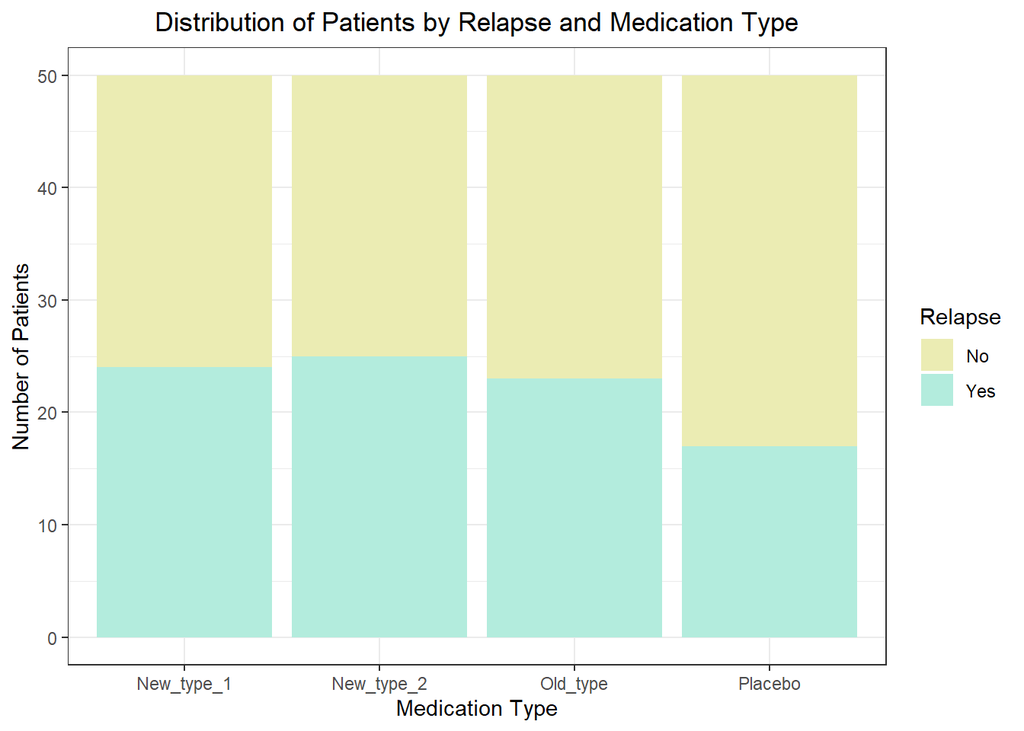

Here we can see fully balanced groups. In this case, the analysis of variance (ANOVA) should behave well and be robust to some violations of assumptions if they arise.

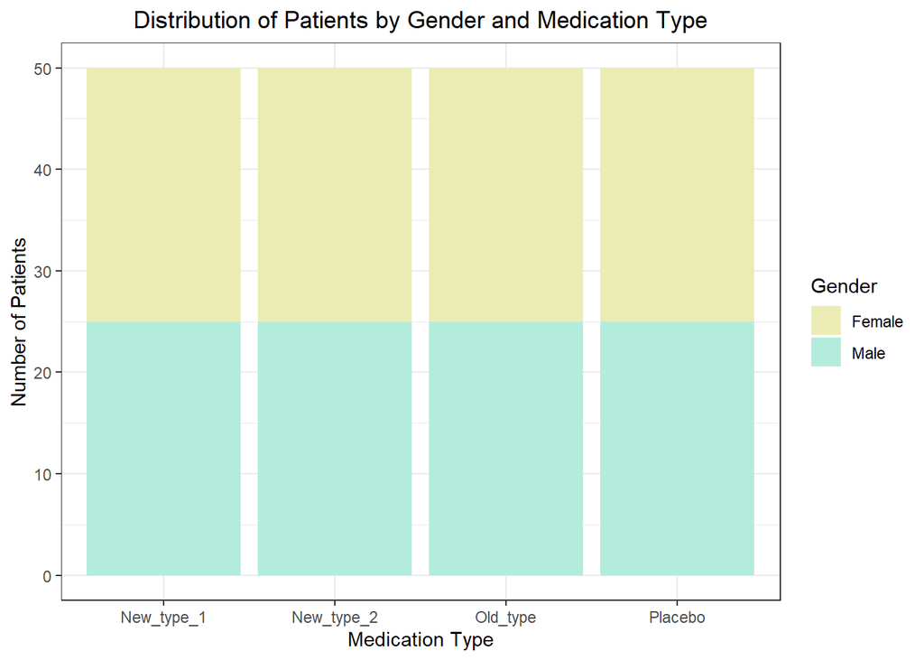

These data already suggest that the medications may work differently depending on the patient’s gender. To confirm this, we will need to perform a two-way ANOVA.

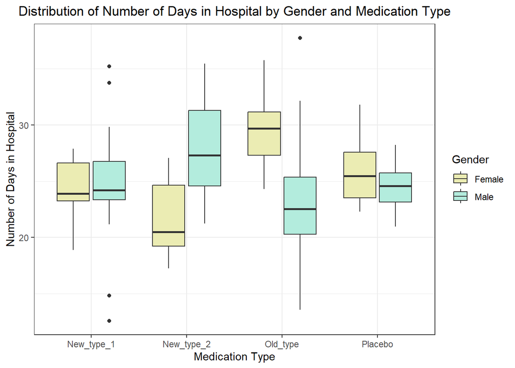

# 3 Analysis of variance

## 3.1 Model Building

Let’s build a linear model based on the factors gender and drug_type and conduct a two-way analysis of variance (ANOVA).

```
## Anova Table (Type II tests)
##
## Response: days_in_hospital
##           Sum Sq  Df F value Pr(>F)
## gender       7.1   1   0.404 0.5258
## drug_type   89.0   3   1.696 0.1692
## Residuals 3409.7 195
```

We can see that in the case of the model without interaction between the predictors, none of them significantly influence the dependent variable.

## 3.2 Checking Model Assumptions

Let’s check the assumptions of this model.

The Cook’s distance plot looks good. We can say that there are no influential observations.

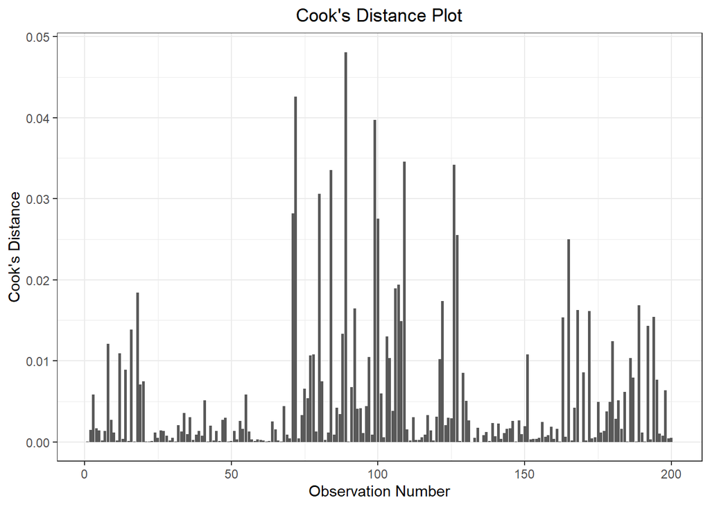

The residual plots don’t look very good. There are many observations beyond two standard deviations, and we also have non-uniform distribution of residuals across groups. We can also see that the variances across groups differ somewhat, but since the number of observations in the groups is equal, the ANOVA should be robust to this.

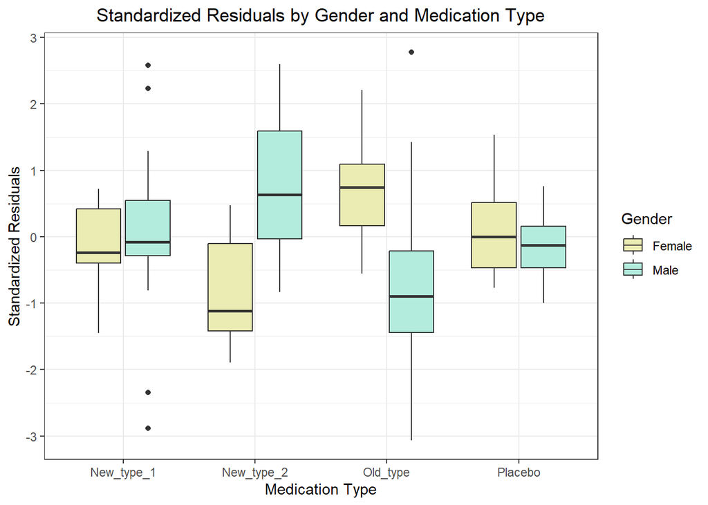

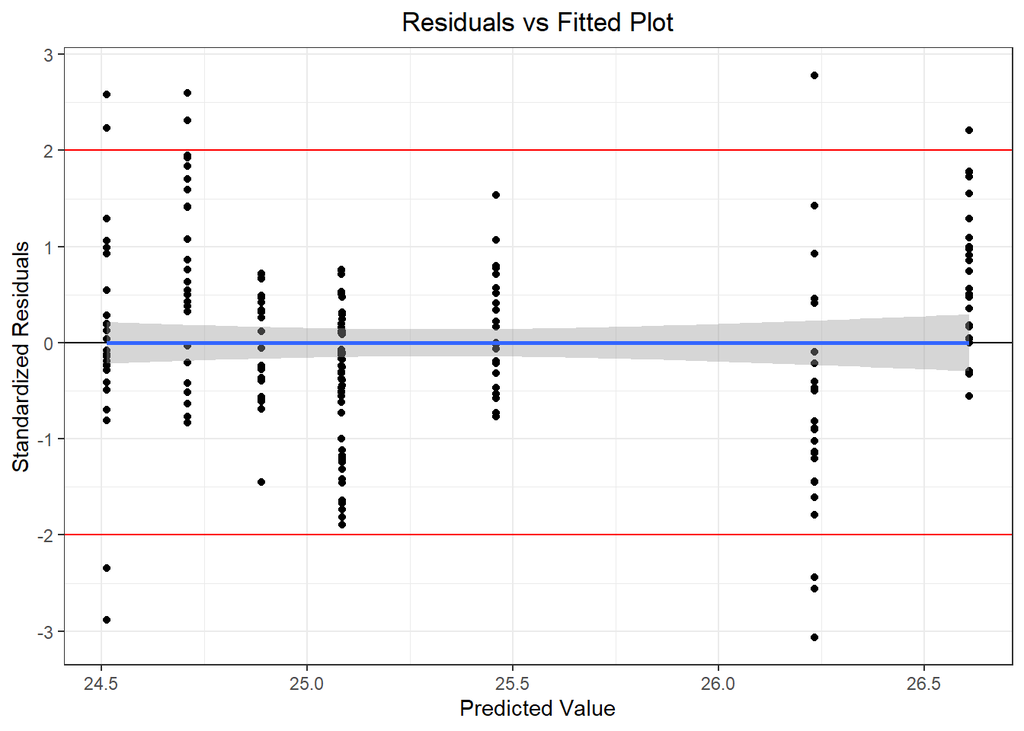

Overall, the residual distribution does not significantly deviate from normality.

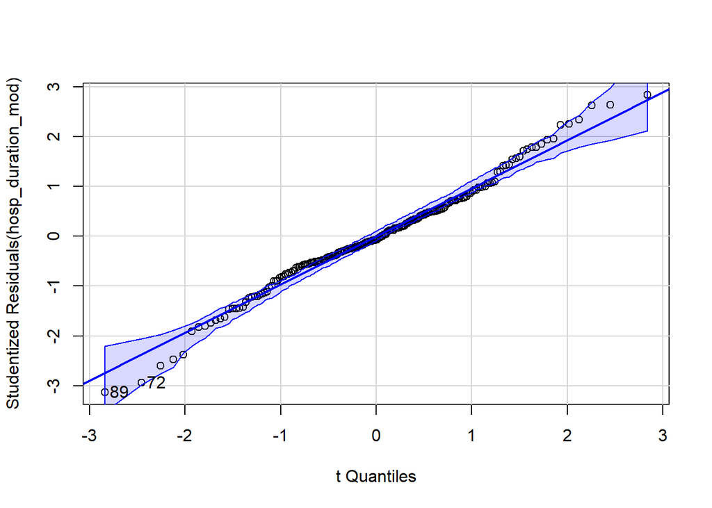

```
## [1] 72 89
```

```
##
##  Shapiro-Wilk normality test
##
## data:  mod_diag$.resid
## W = 0.98691, p-value = 0.06186
```

## 3.3 Model with Interaction of Predictors

Based on the residual plots and the distribution of the number of days in the hospital depending on gender and medication, we can assume that something is missing in our model. It’s time to try adding the interaction between the predictors.

```
## Anova Table (Type II tests)
##
## Response: days_in_hospital
##                   Sum Sq  Df F value    Pr(>F)
## gender              7.06   1  0.5491   0.45961
## drug_type          88.97   3  2.3049   0.07818 .
## gender:drug_type  939.40   3 24.3384 2.158e-13 ***
## Residuals        2470.25 192
## ---
## Signif. codes:  0 '***' 0.001 '**' 0.01 '*' 0.05 '.' 0.1 ' ' 1
```

We can see that the interaction between the predictors has a significant impact on the dependent variable.

Let’s perform diagnostics on the resulting model again.

The Cook’s distance plot still looks normal.

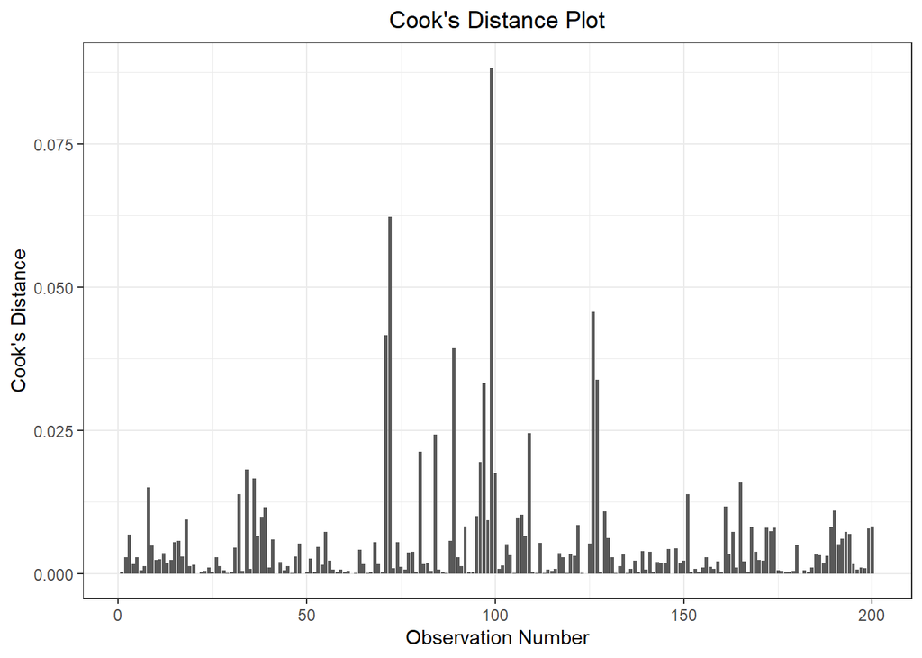

However, the residuals plot has improved significantly: there are fewer observations beyond two standard deviations, and the residual distribution across the groups is approximately uniform.

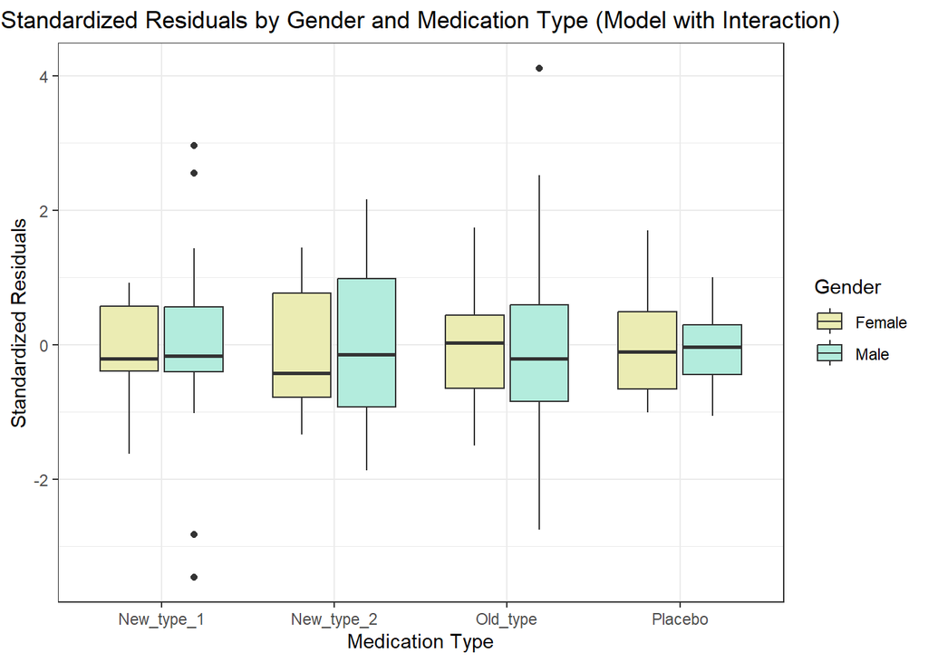

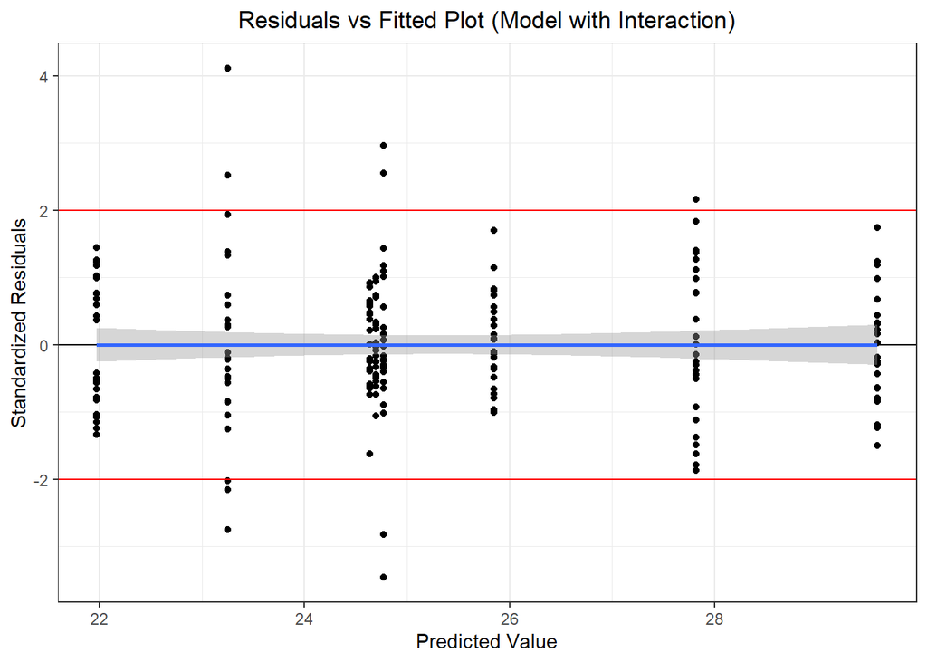

We can see that, generally, we cannot say that the residual distribution does not differ from normality, but in this case, it is not critical due to the robustness of ANOVA.

```
##
##  Shapiro-Wilk normality test
##
## data:  inter_mod_diag$.resid
## W = 0.97686, p-value = 0.002181
```

## 3.4 Interpretation of Results

```
## Anova Table (Type II tests)
##
## Response: days_in_hospital
##                   Sum Sq  Df F value    Pr(>F)
## gender              7.06   1  0.5491   0.45961
## drug_type          88.97   3  2.3049   0.07818 .
## gender:drug_type  939.40   3 24.3384 2.158e-13 ***
## Residuals        2470.25 192
## ---
## Signif. codes:  0 '***' 0.001 '**' 0.01 '*' 0.05 '.' 0.1 ' ' 1
```

The interaction between the predictors turned out to be significant. The combination of factors such as gender and medication significantly affects the average number of days a person spends in the hospital (F = 24.3384, p_value ≈ 0, df1 = 3, df2 = 192).

# 4 Post-hoc tests

ANOVA only tells us whether a factor has an overall effect, but it doesn’t specify which groups are different. To find this out, post-hoc tests need to be performed. Post-hoc tests are a series of pairwise comparisons of group means after a significant effect of the factor has been identified. They differ from ordinary pairwise comparisons in that they take into account the number of comparisons and the magnitude of the differences between the means.

In this work, I will use Tukey’s post-hoc test.

```r
summary(drug_data)
```

```
##     gender         age             drug_type  is_relapse       id
##  female:100   Min.   :22.00   New_type_1:50   0:111      Min.   :  1.00
##  male  :100   1st Qu.:28.00   New_type_2:50   1: 89      1st Qu.: 50.75
##               Median :30.00   Old_type  :50              Median :100.50
##               Mean   :30.09   Placebo   :50              Mean   :100.50
##               3rd Qu.:32.00                              3rd Qu.:150.25
##               Max.   :37.00                              Max.   :200.00
##
##  days_in_hospital             сondition
##  Min.   :12.61    female_New_type_1:25
##  1st Qu.:22.94    female_New_type_2:25
##  Median :25.10    female_Old_type  :25
##  Mean   :25.32    female_Placebo   :25
##  3rd Qu.:27.82    male_New_type_1  :25
##  Max.   :37.72    male_New_type_2  :25
##                   (Other)          :50
```

```
##
##   Simultaneous Tests for General Linear Hypotheses
##
## Multiple Comparisons of Means: Tukey Contrasts
##
##
## Fit: lm(formula = days_in_hospital ~ condition - 1, data = drug_data)
##
## Linear Hypotheses:
##                                            Estimate Std. Error t value Pr(>|t|)
## female_New_type_2 - female_New_type_1 == 0 -2.66186    1.01453  -2.624  0.15349
## female_Old_type - female_New_type_1 == 0    4.95722    1.01453   4.886  < 0.001
## female_Placebo - female_New_type_1 == 0     1.21043    1.01453   1.193  0.93308
## male_New_type_1 - female_New_type_1 == 0    0.13393    1.01453   0.132  1.00000
## male_New_type_2 - female_New_type_1 == 0    3.18670    1.01453   3.141  0.04008
## male_Old_type - female_New_type_1 == 0     -1.38133    1.01453  -1.362  0.87327
## male_Placebo - female_New_type_1 == 0       0.06298    1.01453   0.062  1.00000
## female_Old_type - female_New_type_2 == 0    7.61908    1.01453   7.510  < 0.001
## female_Placebo - female_New_type_2 == 0     3.87229    1.01453   3.817  0.00451
## male_New_type_1 - female_New_type_2 == 0    2.79580    1.01453   2.756  0.11322
## male_New_type_2 - female_New_type_2 == 0    5.84856    1.01453   5.765  < 0.001
## male_Old_type - female_New_type_2 == 0      1.28053    1.01453   1.262  0.91150
## male_Placebo - female_New_type_2 == 0       2.72484    1.01453   2.686  0.13326
## female_Placebo - female_Old_type == 0      -3.74679    1.01453  -3.693  0.00699
## male_New_type_1 - female_Old_type == 0     -4.82328    1.01453  -4.754  < 0.001
## male_New_type_2 - female_Old_type == 0     -1.77052    1.01453  -1.745  0.65757
## male_Old_type - female_Old_type == 0       -6.33855    1.01453  -6.248  < 0.001
## male_Placebo - female_Old_type == 0        -4.89424    1.01453  -4.824  < 0.001
## male_New_type_1 - female_Placebo == 0      -1.07649    1.01453  -1.061  0.96391
## male_New_type_2 - female_Placebo == 0       1.97627    1.01453   1.948  0.51994
## male_Old_type - female_Placebo == 0        -2.59176    1.01453  -2.555  0.17925
## male_Placebo - female_Placebo == 0         -1.14745    1.01453  -1.131  0.94923
## male_New_type_2 - male_New_type_1 == 0      3.05276    1.01453   3.009  0.05828
## male_Old_type - male_New_type_1 == 0       -1.51526    1.01453  -1.494  0.81012
## male_Placebo - male_New_type_1 == 0        -0.07096    1.01453  -0.070  1.00000
## male_Old_type - male_New_type_2 == 0       -4.56803    1.01453  -4.503  < 0.001
## male_Placebo - male_New_type_2 == 0        -3.12372    1.01453  -3.079  0.04838
## male_Placebo - male_Old_type == 0           1.44431    1.01453   1.424  0.84541
##
## female_New_type_2 - female_New_type_1 == 0
```

[output cut: 15 more lines]

```
## male_Old_type - female_Old_type == 0       ***
## male_Placebo - female_Old_type == 0        ***
## male_New_type_1 - female_Placebo == 0
## male_New_type_2 - female_Placebo == 0
## male_Old_type - female_Placebo == 0
## male_Placebo - female_Placebo == 0
## male_New_type_2 - male_New_type_1 == 0     .
## male_Old_type - male_New_type_1 == 0
## male_Placebo - male_New_type_1 == 0
## male_Old_type - male_New_type_2 == 0       ***
## male_Placebo - male_New_type_2 == 0        *
## male_Placebo - male_Old_type == 0
## ---
## Signif. codes:  0 '***' 0.001 '**' 0.01 '*' 0.05 '.' 0.1 ' ' 1
## (Adjusted p values reported -- single-step method)
```

In this case, we see that differences were found between a large number of groups. The main results we can take away here are that the correct medication should be selected for the patient based on their gender to speed up recovery (in some cases, the wrong medication might even slow down the recovery process).